# Jupyter Notebooks

Das ist eine Einführung in Jupyter Notebooks, warum sie toll sind und wie man sie im Unterricht einsetzen kann.

- Interaktives Skript
- Einfach Verteilbar
- Sehr viele Möglichkeiten
- Läuft auf allen Geräten (Browser)
  - Kann aber auch lokal laufen
- Slides können direkt erstellt werden
- Automatisches korrigieren von Aufgaben

## Erstes Beispiel

Slides können ganz einfach erstellt werden, und man kann auch Latex verwenden.

$$ y = m \cdot x+b$$

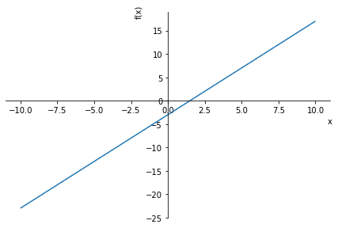

```
<sympy.plotting.plot.Plot at 0x7f7d827d30a0>
```

```python
%matplotlib inline
from sympy import *
from matplotlib import pyplot as plt

x = symbols('x')
m = 2; b = -3
plot(m*x + b)
```

## Aufgabe Schritt für Schritt vorrechnen

Bestimmen Sie den Punkt der auf der Gerade $f(x) = y = 2 \cdot x - 1$, der dem Ursprung am nächsten liegt.

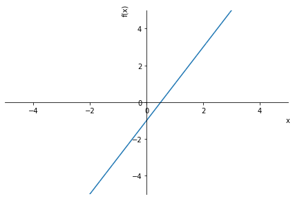

```
<sympy.plotting.plot.Plot at 0x7f7d82602d90>
```

```python
# Skizze der Geraden

x = symbols('x')
f = 2 * x - 1
plot(f, xlim=[-5, 5], ylim=[-5,5])
```

### Der Abstand $d$

Den Abstand zum Ursprung können wir als $d$ definieren:

$$ \begin{align*} d^2 &= x^2 + f(x)^2 \\ d^2 &= x^2 + (2 \cdot x - 1)^2 \end{align*} $$

$$ d = x^2 + (2 \cdot x - 1)^2 $$

[figure not shown]

```
<sympy.plotting.plot.Plot at 0x7f7d8007ce80>
```

```python
# d definieren und Skizzieren
d = x**2 + (2*x - 1)**2

plot(f, d, xlim=[-5, 5], ylim=[-5,5])
```

### $d$ vereinfachen und den Scheitelpunkt berechnen

$$ S = \left(- \frac{b}{2\cdot a}, \frac{-b^2 + 4 \cdot a \cdot c}{4 \cdot a} \right) $$

```python
print(d)
# d vereinfachen
d = expand(d)
print(d)
```

```
x**2 + (2*x - 1)**2
```

$\displaystyle 5 x^{2} - 4 x + 1$

```python
# x-Koordinate von S berechnen

x_s = - (-4)/(2*5)
print(x_s)
```

```
0.4
```

```python
# x_s in f einsetzen
y_s = 2 * x_s -1

print(x_s, y_s)
```

```
0.4 -0.19999999999999996
```

### Lösung

Der Punkt auf der Geraden $f$, der dem Ursprung am nächsten ist, ist der Punkt $P = (0.4, -0.2)$.

## Vorteil von Jupyter vs andere Tools

Mit Jupyter können wir Code zur Verfügung stellen, der es für die SuS einfacher macht.

- Kontrolle über Funktionalität
- Einfach erweiterbar
- Wenig Abhängigkeit von externen Tools
- Könnte an Prüfungen verwendet werden

### Beispiel Scheitelpunkt

Wir können eine Funktion zur Verfügung stellen, die den Scheitelpunkt berechnet.

```python
def scheitelpunkt(a=1, b=1, c=0):
    x_s = - b/(2*a)
    y_s = (-(b**2) + 4*a*c)/(4*a)
    print(f'Der Scheitelpunkt ist ({x_s}, {y_s})')

scheitelpunkt(a=5, b=-4, c=1)
```

```
Der Scheitelpunkt ist (0.4, 0.2)
```

## Verteilen

Die Jupyter Notebooks können ganz einfach auf Github gestellt werden.

- Versionierung
- Fehler einfach beheben
- Notebooks erweitern
- Interaktive Notebooks mit myBinder

# Algebra mit Python

Python hat eine Bibliothek `sympy` mit der symbolisches rechnen in Python möglich ist.

- Ziemlich umfangreich
- Kann erweitert werden
- Workflows können vereinfacht werden

```python
from sympy import *

a, x = symbols('a x')

f = a*x**2 - 2*x + 4

integrate(f, x)
```

$\displaystyle \frac{a x^{3}}{3} - x^{2} + 4 x$

# Symbolisches integrieren

Mit sympy können wir auch integrieren.

```python
a, x = symbols('a x')
f = a * (1 - 0.25*x**2)

nullstellen = solve(f, x)
print(f'Die Nullstellen von {f} sind: {nullstellen}')
```

```
Die Nullstellen von a*(1 - 0.25*x**2) sind: [-2.00000000000000, 2.00000000000000]
```

```python
F = integrate(f, (x, -2, 2))
area = 8
solve(F-area, a)
```

```
[3.00000000000000]
```

## Funktionen plotten

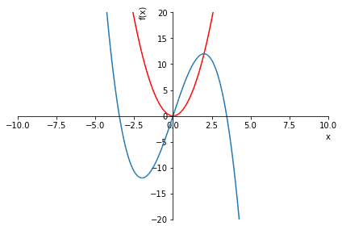

```python
f = 3*x**2
g = -3/4*x**3+9*x
p = plot(f, g, xlim=[-10, 10], ylim=[-20, 20], adaptive=False, show=False)
p[0].line_color = 'red'
p.show()
```